# STAT 585 Lab One - Team One

Eryn Blagg, Katherine Goode, Ju Ji, Charlotte Roiger

2/4/2019

Our lab repository can be found [here](https://github.com/EBlagg/585Lab). The following packages were used in this write up.

```r
# Load in requisite libraries
library(tidyverse)
library(ggmap)
library(maps)
library(mapdata)
```

# Part One: Building the Book

**Deliverable (1):** The last word of Chapter 15 is “packages”

**Deliverable (2):** The biggest problem we encountered when trying to build the book is to install all of the packages that the book required to compile. Every time we knitted the book, the execution was halted and `R` would indicate which package would need to be installed. The following packages were required for installation: sloop, vctrs, RSQLite, profvis, bench, ggbeeswarm. Another important thing to note is that the book required the package “emo” which was not available on CRAN. Due to this, we had to use the `devtools` to install “emo” from Hadley’s Git Repo.

# Part Two: US Weather Stations

The code below obtains the weather data in addition to map data for the US.

```r
# Make sure your working directory is pointed to the right file path for
# this lab please
dataDir <- getwd()

# Load in data, chosen to specify start and stopping point for each column
# in data frame
weather <- read_fwf(file.path(dataDir,"ushcn-v2.5-stations.txt"),
                    fwf_cols(country_code = c(1,2),
                             network_code = 3,
                             id_placeholders = c(4,5),
                             coop_id = c(6,11),
                             latitude = c(13,20),
                             longitude = c(22,30),
                             elevation = c(33,37),
                             state = c(39,40),
                             name = c(42,71),
                             comp1 = c(73,78),
                             comp2 = c(80,85),
                             comp3 = c(87,92),
                             utc_offset = c(94,95)))

# Will also use maps from the mapdata package for visualization
usa <- map_data("state")
```

The code below makes some adjustments to the weather and US map datasets such as adding or relabeling time zones to be used in the plot.

```r
# Change elevation to be a numeric rather than factor and create a time zone variable
weather <- weather %>%
  mutate(elevation = as.numeric(elevation),
         time_zone = factor(utc_offset)) %>%
  mutate(time_zone = forcats::fct_recode(time_zone,
                                         "ETZ" = "5", "CTZ" = "6",
                                         "MTZ" = "7", "PTZ" = "8") %>%
           forcats::fct_relevel("CTZ", "ETZ", "MTZ", "PTZ"))

# Create a variable that accounts for the timezone of each state
usa <- usa %>%
  mutate(time_zone = ifelse(region %in% c("maine", "vermont", "new hampshire",
                                          "massachusetts", "rhode island", "conneticut",
                                          "new york", "pennsylvania", "new jersey",
                                          "delaware", "maryland",
                                          "district of columbia", "virginia",
                                          "west virginia", "ohio", "michigan",
                                          "indiana", "north carolina", "south carolina",
                                          "georgia", "florida", "connecticut"),
                            "ETZ",
                            ifelse(region %in% c("wisconsin", "illinois", "kentucky",
                                                 "tennessee", "alabama", "mississippi",
                                                 "minnesota", "iowa", "missouri",
                                                 "arkansas", "louisiana",
                                                 "north dakota", "south dakota",
                                                 "nebraska", "kansas", "oklahoma",
                                                 "texas", ""),
                                   "CTZ",
                                   ifelse(region %in% c("montana", "wyoming",
                                                        "colorado", "new mexico",
                                                        "idaho", "utah", "arizona"),
                                          "MTZ", "PTZ")))) %>%
  mutate(time_zone = factor(time_zone))
```

The code below creates a plot of the latitude versus longitude locations in the weather data plotted on a map of the contiguous US. The states and points are colored by the time zone where the plots are located, and the darkness of the points represents the elevation.

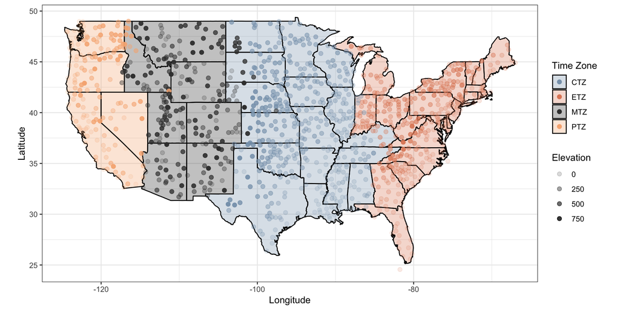

```r
# Visualize elevation, state, and time zone of each station
ggplot() +
  geom_polygon(data = usa,
               aes(x = long, y = lat, group = group, fill = factor(time_zone)),
               alpha = 0.3,
               color = "black") +
  geom_point(data = weather,
             aes(x = longitude, y = latitude, colour = time_zone, alpha = elevation),
             size = 2) +
  coord_fixed(1.3) +
  scale_fill_manual(values = c("#87A1B9", "#E08865", "#3C3C3C", "#F7B281"),
                    name = "Time Zone") +
  scale_color_manual(values = c("#87A1B9", "#E08865", "#3C3C3C", "#F7B281"),
                     name = "Time Zone") +
  labs(x = "Longitude", y = "Latitude", alpha = "Elevation") +
  theme_bw()
```

# Part Three: More Weather Stations

The code below reads in the file and determines the number of files in the folder.

```r
# Untar the file to create a new folder in our repository
# obtain a list of files
numfiles <- untar("ushcn.tavg.latest.raw.tar.gz", list = TRUE)

# Count the number of files in our new folder
length(numfiles)
```

```
## [1] 1219
```

Our team home towns are Omaha, NE; Green Lake, WI; and Minneapolis, MN. From examining the data the only home town that is present in the NOAA dataset is Minneapolis, which is designated “MINNEAPOLIS/ST PAUL AP”. We will now search for the file name. First we need to condense the first four columns into a unified ID number

```r
# Create the unified ID number to find the file name for Minneapolis
weather <- weather %>%
  unite(united_id, country_code, network_code,
        id_placeholders, coop_id, sep = "")

# Let's find the unified ID number for MINNEAPOLIS/ST PAUL AP
weather[weather$name == "MINNEAPOLIS/ST PAUL AP", ]$united_id
```

```
## [1] "USH00215435"
```

The unified ID number for the Minneapolis/St.Paul area is shown above. Now we will find the file name associated with the united ID number.

```r
numfiles[grep("USH00215435", numfiles)]
```

```
## [1] "./ushcn.v2.5.5.20190204/USH00215435.raw.tavg"
```

This should be the file name correlated with the file containing the average temperature for Minneapolis/St. Paul.